# Survey

## Read in data

Here we will read in our class survey data from a csv file. This class survey is a concatonation of responses from the last two years of AMED3002 and 2017’s STAT2012 Cohorts. If you look at the missing data structure, is it obvious which questions have been added to the survey?

```r
survey = read.csv("/home/aidan/Uni/Uni - Sem 1 - 2019/AMED3002/Survey/ClassSurvey.V3.csv")

## size of the data set
dim(survey)
```

```
## [1] 130  55
```

```r
## Take the questions that overlap between Cohorts.

survey = survey[,1:18]


## rename column names


colnames(survey)
```

```
##  [1] "Timestamp"
##  [2] "Survey.ID..make.up.a.name."
##  [3] "Gender"
##  [4] "Postcode.of.where.you.live"
##  [5] "What.introductory.statistic.course.did.you.take."
##  [6] "How.many.university.clubs.are.you.a.member.of."
##  [7] "How.many.hours.per.week.did.you.spend.on.studying.last.year."
##  [8] "What.was.your.study.load.last.year."
##  [9] "What.is.your.favourite.social.media.platform.."
## [10] "How.many.siblings.do.you.have.."
## [11] "How.many.friends.do.you.have.on.Facebook.."
## [12] "What.is.your.average.grade.from.last.year..please.enter.a.number..."
## [13] "Did.you.have.a.pet.growing.up."
## [14] "Do.you.still.live.at.home."
## [15] "How.many.hours.a.week.do.you.spend.exercising."
## [16] "What.is.your.eye.colour."
## [17] "How.many.hours.do.you.work.per.week."
## [18] "What.is.your.favourite.season."
```

```r
oldname = colnames(survey)
newname = c("Time", "ID", "Gender", "Postcode", "StatsCourse",
            "Clubs", "StudyTime", "StudyLoad", "SocialMedia",
            "Siblings", "FBFriends", "Grade", "Pet",
            "Home", "ExerciseTime", "Eyecolor", "Working",
            "Season")
colnames(survey) = newname
```

## Data Cleaning

The survey was collected in such a way so as to demonstrate the kind of responses that you might get if you aren’t specific with your questions. We clearly have some dirty data and will attempt to clean it up.

```r
# Clean up the results a little bit.
survey$Grade = as.character(survey$Grade)
survey$Grade[survey$Grade=='n/a'] = NA
survey$Grade[survey$Grade=='50-60'] = 55
survey$Grade[survey$Grade=='pass'] = 50
survey$Grade[survey$Grade=='D'] = 75
survey$Grade[survey$Grade=='c'] = 65
survey$Grade[survey$Grade=='HD'] = 85
survey$Grade = as.numeric(survey$Grade)
survey$StudyTime = as.character(survey$StudyTime)
survey$StudyTime[survey$StudyTime=='5-Jun'] = NA
survey$StudyTime[survey$StudyTime=='8hr'] = 8
survey$StudyTime[survey$StudyTime=='28 hours'] = 28
survey$StudyTime[survey$StudyTime=='8hr'] = 8
survey$StudyTime[survey$StudyTime=="didn't start uni maybe 6h"] = 6
survey$StudyTime[survey$StudyTime=='not sure'] = NA
survey$StudyTime[survey$StudyTime=='not sure '] = NA
survey$StudyTime[survey$StudyTime=='20-'] = 22
survey$StudyTime[survey$StudyTime=='20-25?'] = 22.5
survey$StudyTime[survey$StudyTime=='n/a'] = NA
survey$StudyTime[survey$StudyTime=='25+'] = NA
survey$StudyTime[survey$StudyTime=='25+'] = NA
survey$StudyTime[survey$StudyTime=='10 (excluding attending university) '] = 10
survey$StudyTime[survey$StudyTime=='10?'] = 10
survey$StudyTime[survey$StudyTime=='I have no idea '] = NA
survey$StudyTime[survey$StudyTime=='10-12 extracrricular'] = 11
survey$StudyTime[survey$StudyTime=='Too many'] = NA
survey$StudyTime[survey$StudyTime=='too many'] = NA
survey$StudyTime[survey$StudyTime=='25 hours a week'] = 25
survey$StudyTime[survey$StudyTime=='20-24'] = 22
survey$StudyTime = as.numeric(survey$StudyTime)
FB = survey$FBFriends
FB = gsub('\\+','',FB)
FB = gsub('~','',FB)
FB = gsub(' ish','',FB)
FB[FB=="Don't have facebook"] = 0
FB[FB=="Don't have FB"] = 0
FB[FB=="none (not in facebook)"] = 0
FB[FB=="Cant remember"] = NA
FB[FB=="not sure"] = NA
FB[FB=="I don't know"] = NA
FB[FB=="do not know"] = NA
FB = as.numeric(FB)
FB[is.na(FB)] = mean(FB,na.rm = TRUE)
survey[,"FBFriends"] = FB


ET = as.character(survey$ExerciseTime)
ET[ET==''] = 0
ET[ET=='5-Jun'] = 5.5
ET[ET=='2-Mar'] = 2.5
ET[ET=='4-May'] = 4.5
ET[ET=='6 hr'] = 6
ET[ET=='none'] = 0
ET[ET=='2 hours'] = 2
survey[,"ExerciseTime"] = as.numeric(ET)


WK = as.character(survey[,"Working"])
WK[WK==''] = 0
WK[WK=='18 hours'] = 18
WK[WK=='8-Dec'] = NA
WK[WK=='168'] = NA
WK[WK=='none'] = 0
survey[,"Working"] = as.numeric(WK)


PT = as.character(survey$Pet)
PT[PT==''] = NA
survey$Pet = as.factor(PT)


HM = as.character(survey$Home)
HM[HM==''] = NA
survey$Home = as.factor(HM)


SB = as.character(survey$Siblings)
SB[SB=='none'] = 0
SB[SB=='165'] = NA
SB[SB=='one'] = 1
SB[SB=='One'] = 1
survey$Siblings = as.numeric(SB)


CB = as.character(survey$Clubs)
CB[grep('none',CB,ignore.case = TRUE)] = 0
CB[CB=="10+"] = 10
CB[CB=="18 or so? executive of 9"] = 18
survey$Clubs = as.numeric(CB)


SN = as.character(survey$Season)
SN[SN==''] = NA
survey$Season = as.factor(SN)

survey$Cohort = (as.Date(survey$Time)>"2018-01-01") + (as.Date(survey$Time)>"2019-01-01")
survey$Cohort = factor(survey$Cohort,levels = c(0,1,2), labels = c('STAT2012','AMED3002.2018','AMED3002.2019'))
```

## Example: Grades

Let’s ask a very reasonable question. Is there a relationship between the amount of time someone spends studying and their grades?

### Take a look

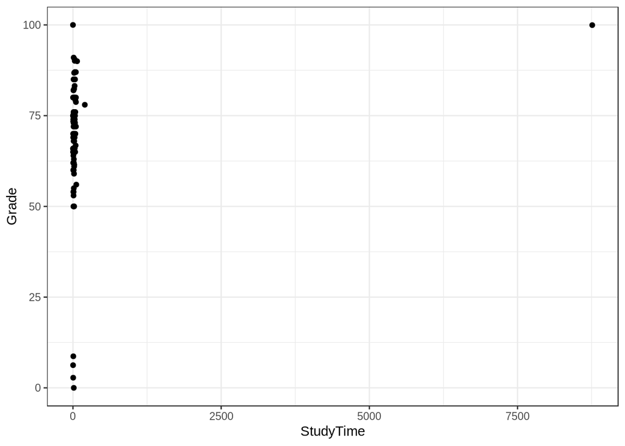

```r
library(tidyverse)
ggplot(survey,aes(x = StudyTime,y =Grade))+geom_point() + theme_bw()
```

There is clearly an outlier, let’s remove it and look again…

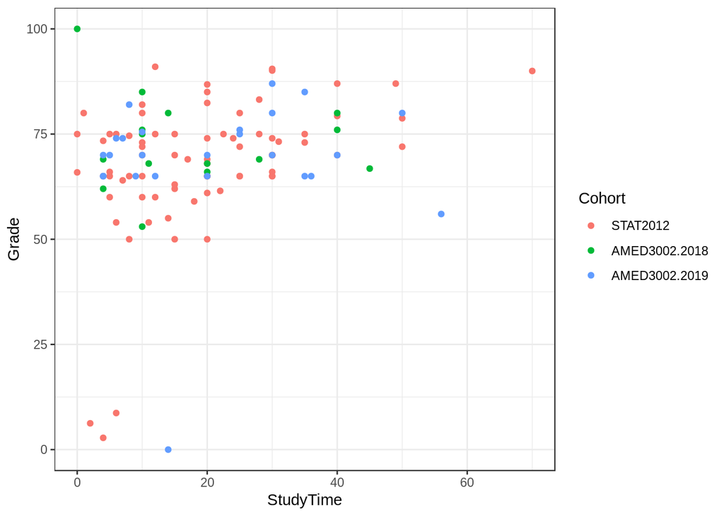

```r
# Remove outlier
survey2 = survey[which(survey$StudyTime<100),]
ggplot(survey2,aes(x = StudyTime,y =Grade , colour = Cohort))+geom_point() + theme_bw()
```

### Testing

Now lets test to see if there is a relationship between study time and grades. What do we see here? What conclusions should we make, Is there anything we should be concerned about? Is this a good fit?

```r
fit = lm(Grade~StudyTime,survey2)
summary(fit)
```

```
##
## Call:
## lm(formula = Grade ~ StudyTime, data = survey2)
##
## Residuals:
##     Min      1Q  Median      3Q     Max
## -67.157  -4.666   0.959   8.584  37.206
##
## Coefficients:
##             Estimate Std. Error t value Pr(>|t|)
## (Intercept)  62.7943     2.3940  26.230  < 2e-16 ***
## StudyTime     0.3116     0.1000   3.116  0.00232 **
## ---
## Signif. codes:  0 '***' 0.001 '**' 0.01 '*' 0.05 '.' 0.1 ' ' 1
##
## Residual standard error: 14.84 on 114 degrees of freedom
##   (2 observations deleted due to missingness)
## Multiple R-squared:  0.07848,    Adjusted R-squared:  0.0704
## F-statistic: 9.709 on 1 and 114 DF,  p-value: 0.00232
```

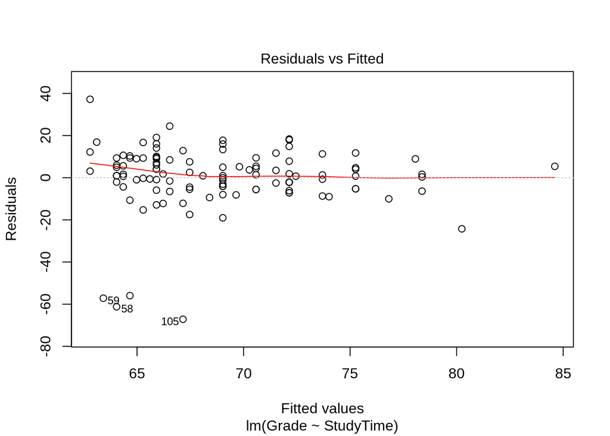

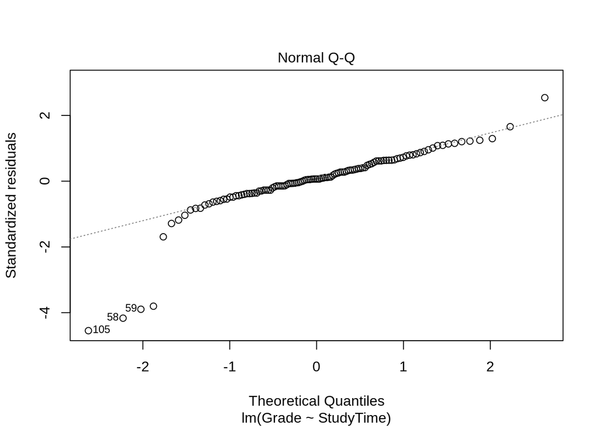

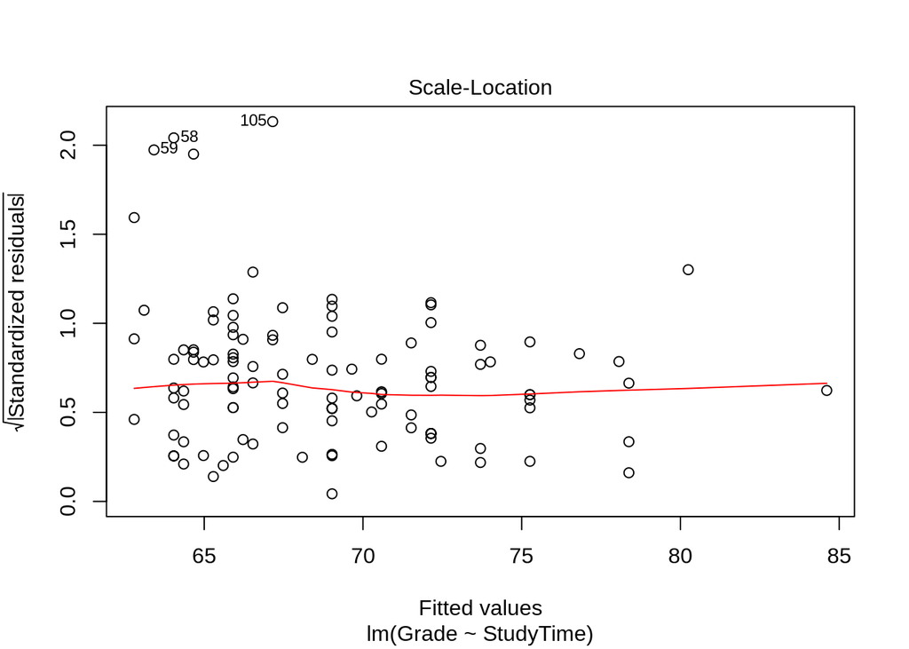

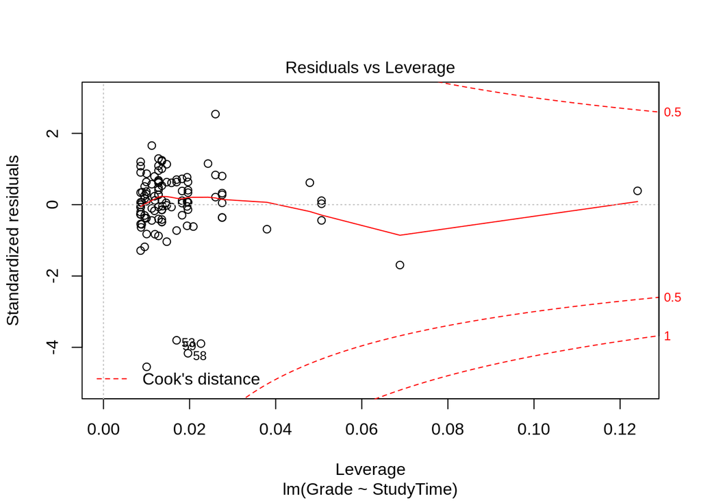

```r
plot(fit)
```

We might be worried about the people with low grades. Lets remove them to see if our results are robust

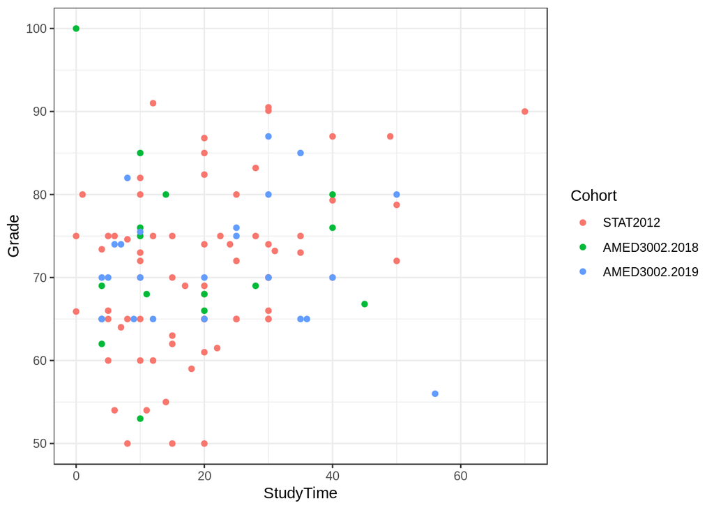

```r
# Remove outlier
survey3 = survey2[survey2$Grade > 40,]
# Or
survey3 = filter(survey2,Grade > 40)


ggplot(survey3,aes(x = StudyTime,y =Grade , colour = Cohort))+geom_point() + theme_bw()
```

```r
fit = lm(Grade~StudyTime,survey3)
summary(fit)
```

```
##
## Call:
## lm(formula = Grade ~ StudyTime, data = survey3)
##
## Residuals:
##     Min      1Q  Median      3Q     Max
## -21.190  -6.190  -0.493   5.359  32.025
##
## Coefficients:
##             Estimate Std. Error t value Pr(>|t|)
## (Intercept) 67.97535    1.54663  43.950   <2e-16 ***
## StudyTime    0.16071    0.06361   2.527   0.0129 *
## ---
## Signif. codes:  0 '***' 0.001 '**' 0.01 '*' 0.05 '.' 0.1 ' ' 1
##
## Residual standard error: 9.269 on 110 degrees of freedom
## Multiple R-squared:  0.05485,    Adjusted R-squared:  0.04626
## F-statistic: 6.383 on 1 and 110 DF,  p-value: 0.01294
```

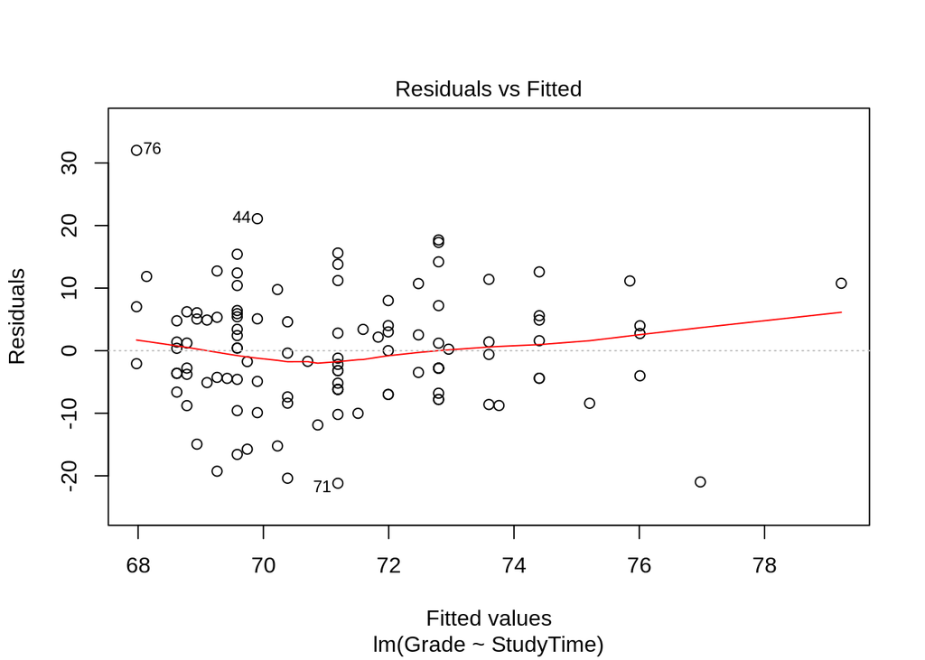

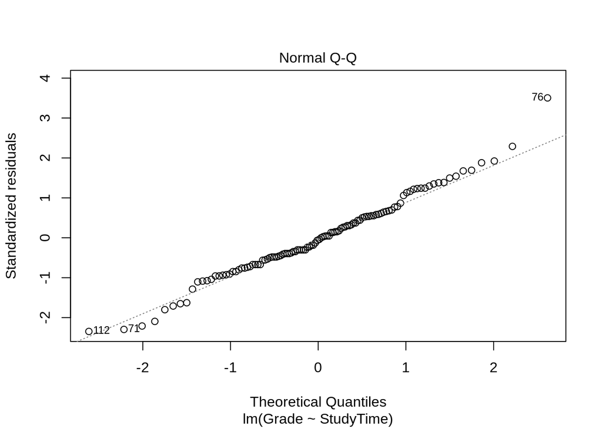

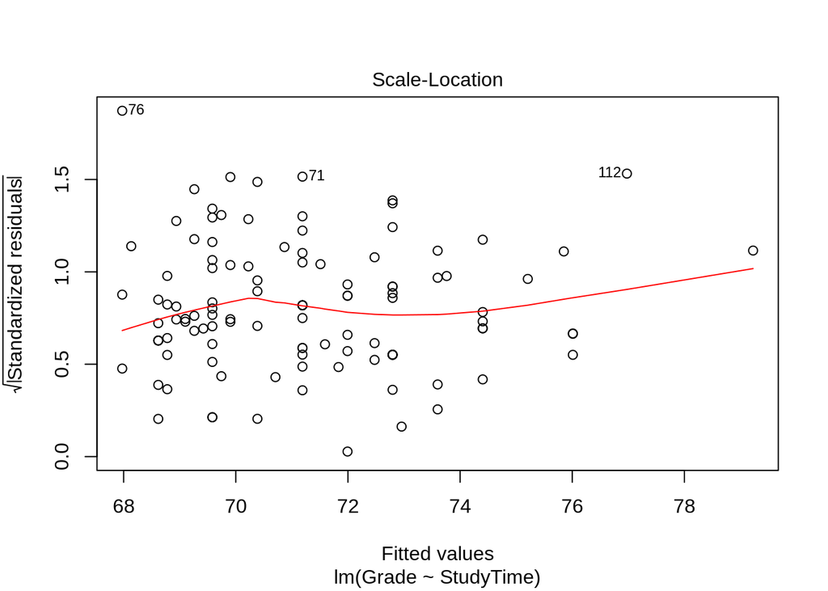

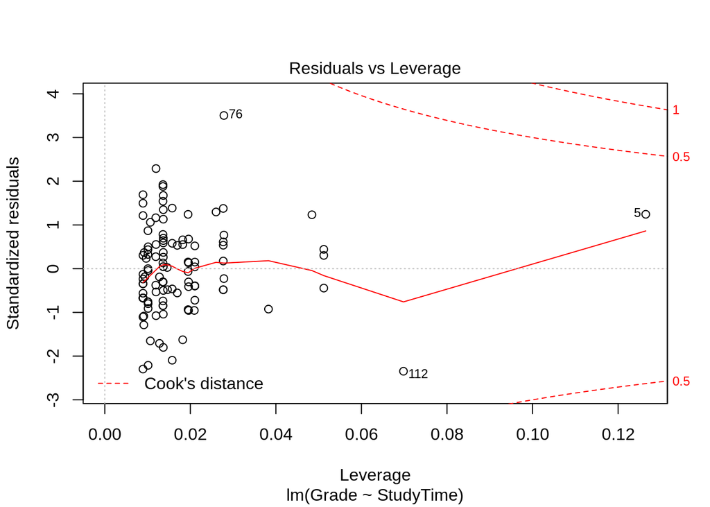

```r
plot(fit)
```

### What trend?

We can fit regression line using ggplot as well. What do you think the shaded area means?

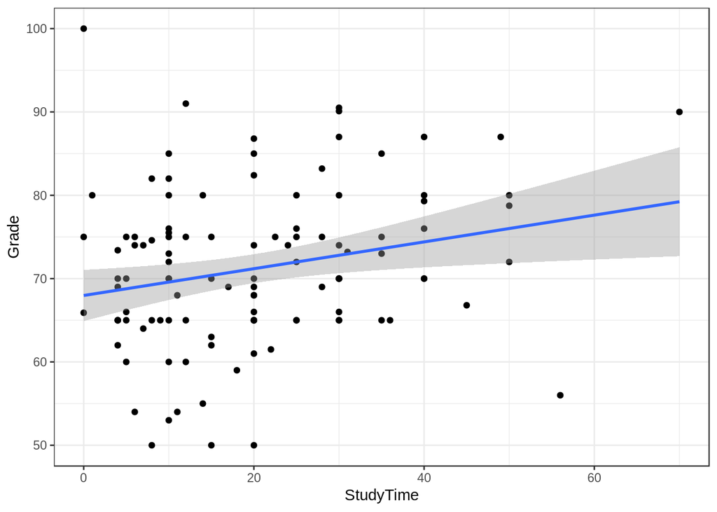

```r
ggplot(survey3,aes(x = StudyTime,y =Grade ))+geom_point() + theme_bw() + geom_smooth(method = 'lm')
```

Lets colour by cohort

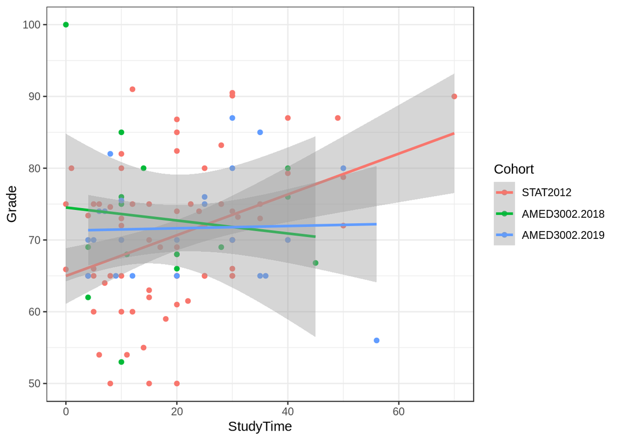

```r
ggplot(survey3,aes(x = StudyTime,y =Grade ,colour = Cohort))+geom_point() + theme_bw() + geom_smooth(method = 'lm')
```

## Multiple linear regression

We measure more than one variable. How well can we predict someones grades? If we fit a model with all the variables is it a good or reasonable fit? What conclusions could we make?

```r
survey4 = survey2[,c('Grade','StudyTime','Cohort','FBFriends','ExerciseTime','Working',"Pet","Home",'Clubs','Season')]
survey4 = survey4[rowSums(is.na(survey4))==0,]
fit = lm(Grade~.,survey4)
summary(fit)
```

```
##
## Call:
## lm(formula = Grade ~ ., data = survey4)
##
## Residuals:
##     Min      1Q  Median      3Q     Max
## -59.443  -5.085   1.683   8.349  22.163
##
## Coefficients:
##                       Estimate Std. Error t value Pr(>|t|)
## (Intercept)         58.0038155  4.6999394  12.341  < 2e-16 ***
## StudyTime            0.3365136  0.1157598   2.907  0.00449 **
## CohortAMED3002.2018  4.3826187  4.5132523   0.971  0.33386
## CohortAMED3002.2019  2.1502040  4.0554230   0.530  0.59715
## FBFriends            0.0002353  0.0042876   0.055  0.95635
## ExerciseTime         0.2485584  0.3734320   0.666  0.50720
## Working              0.2304818  0.1450060   1.589  0.11511
## PetYes              -2.6552013  3.2087443  -0.827  0.40993
## HomeYes              6.0680555  3.0152434   2.012  0.04686 *
## Clubs               -0.1996900  0.8395640  -0.238  0.81248
## SeasonSpring        -3.4042406  4.0672579  -0.837  0.40460
## SeasonSummer        -1.2651441  4.0244012  -0.314  0.75390
## SeasonWinter        -2.6248442  4.4527003  -0.589  0.55686
## ---
## Signif. codes:  0 '***' 0.001 '**' 0.01 '*' 0.05 '.' 0.1 ' ' 1
##
## Residual standard error: 15.01 on 100 degrees of freedom
## Multiple R-squared:  0.1599, Adjusted R-squared:  0.05907
## F-statistic: 1.586 on 12 and 100 DF,  p-value: 0.1077
```

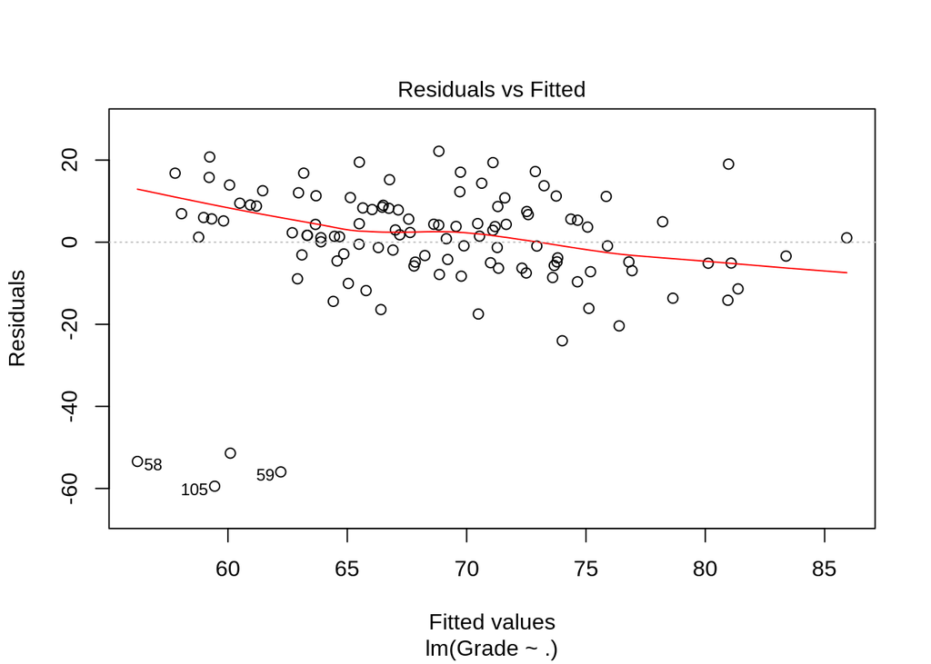

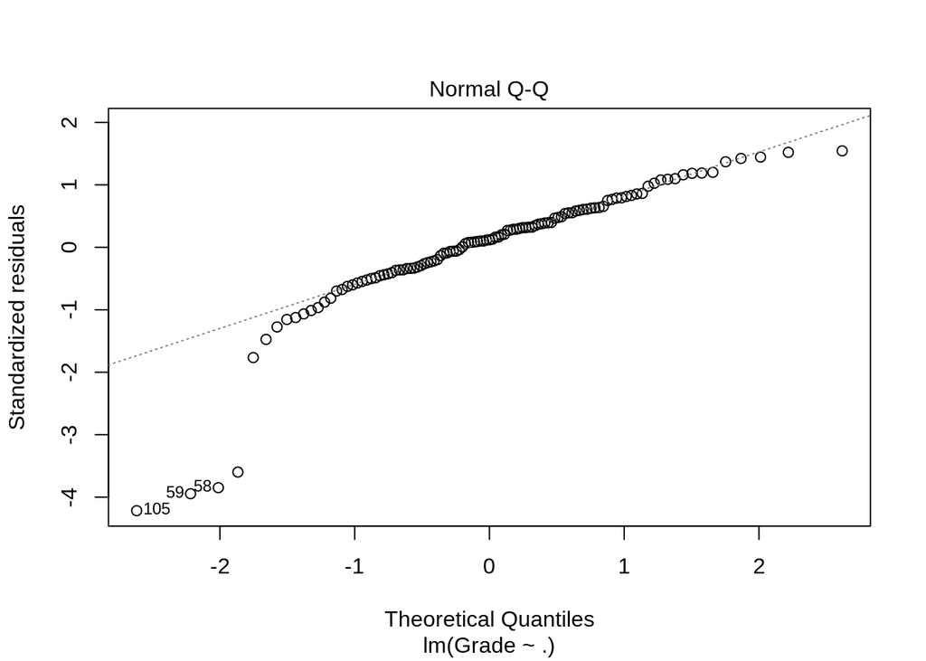

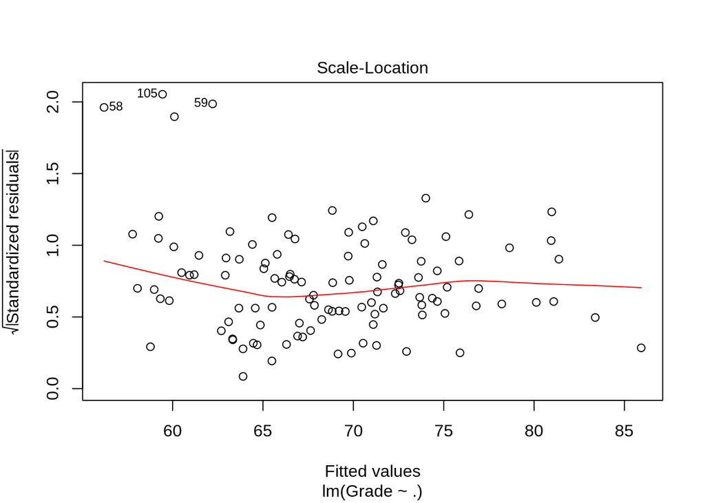

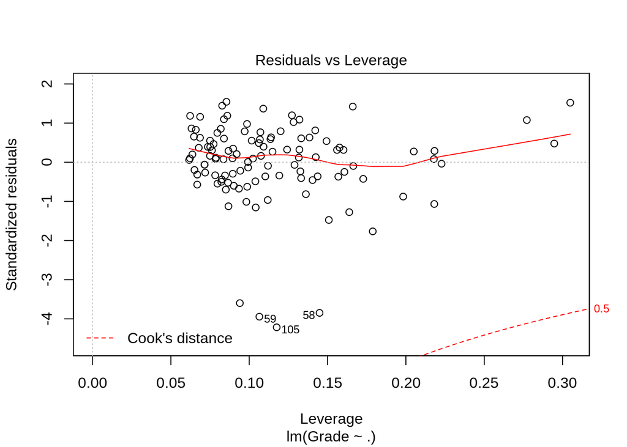

```r
plot(fit)
```

Use the data with outliers removed

```r
survey4 = survey3[,c('Grade','StudyTime','Cohort','FBFriends','ExerciseTime','Working',"Pet","Home",'Clubs','Season')]
survey4 = survey4[rowSums(is.na(survey4))==0,]
fit = lm(Grade~.,survey4)
summary(fit)
```

```
##
## Call:
## lm(formula = Grade ~ ., data = survey4)
##
## Residuals:
##      Min       1Q   Median       3Q      Max
## -21.3001  -5.2593   0.0083   6.3049  23.6802
##
## Coefficients:
##                      Estimate Std. Error t value Pr(>|t|)
## (Intercept)         66.164799   3.029903  21.837   <2e-16 ***
## StudyTime            0.151520   0.073713   2.056   0.0425 *
## CohortAMED3002.2018  1.289193   2.824900   0.456   0.6492
## CohortAMED3002.2019 -0.550627   2.612028  -0.211   0.8335
## FBFriends            0.003834   0.002825   1.357   0.1780
## ExerciseTime        -0.086378   0.235682  -0.367   0.7148
## Working              0.062230   0.091987   0.677   0.5003
## PetYes               0.863061   2.025952   0.426   0.6711
## HomeYes              3.013415   1.910516   1.577   0.1180
## Clubs               -0.213239   0.533232  -0.400   0.6901
## SeasonSpring        -3.566748   2.572918  -1.386   0.1689
## SeasonSummer        -1.738940   2.552360  -0.681   0.4973
## SeasonWinter        -2.070995   2.830692  -0.732   0.4662
## ---
## Signif. codes:  0 '***' 0.001 '**' 0.01 '*' 0.05 '.' 0.1 ' ' 1
##
## Residual standard error: 9.34 on 96 degrees of freedom
## Multiple R-squared:  0.1311, Adjusted R-squared:  0.02251
## F-statistic: 1.207 on 12 and 96 DF,  p-value: 0.2894
```

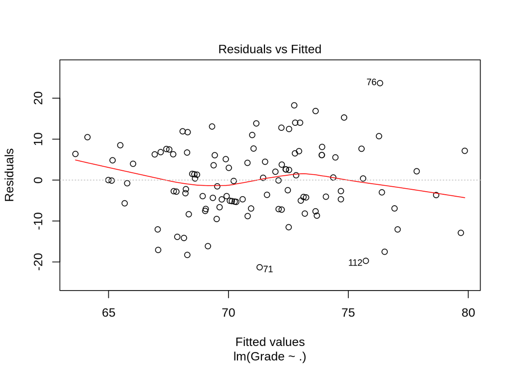

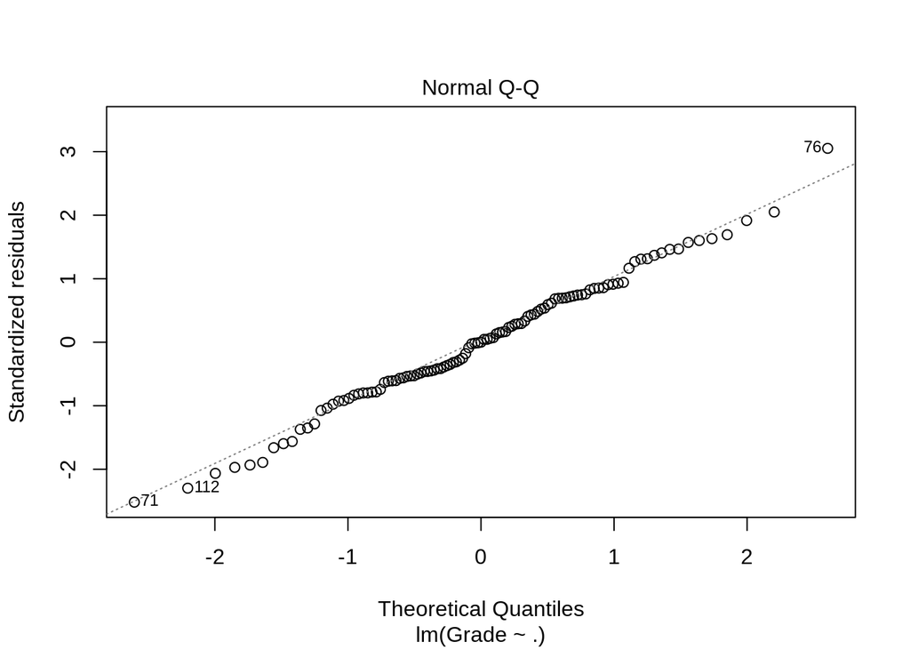

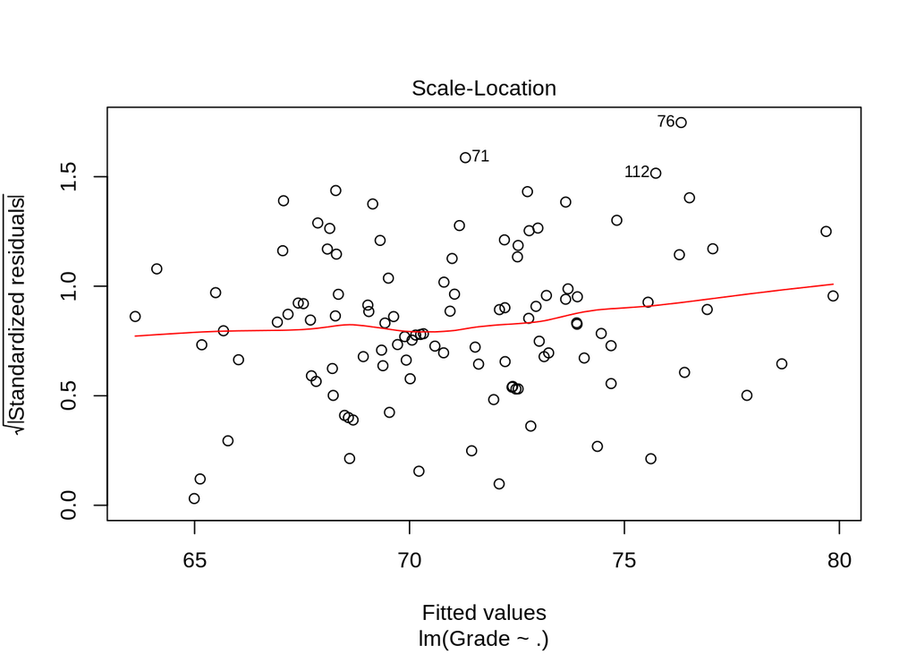

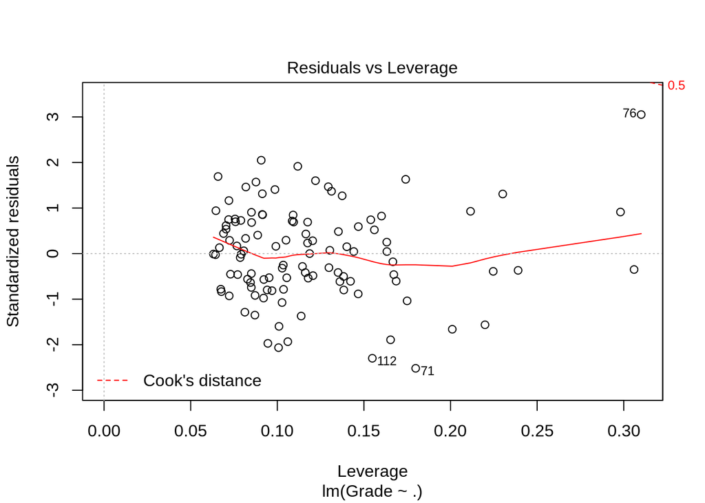

```r
plot(fit)
```

## Model selection

This model is quite complex. Could we construct a simpler model that contains the same amount of information?

```r
#Full model
fit1 <- lm(Grade ~ ., survey4)
#Null model
fit2 <- lm(Grade ~ 1, survey4)

## Forward stepwise model selection using AIC criterion
fit = step(lm(Grade~1,survey4),direction = "forward",scope = list(lower=fit2,upper=fit1))
```

```
## Start:  AIC=490.55
## Grade ~ 1
##
##                Df Sum of Sq    RSS    AIC
## + StudyTime     1    319.41 9318.4 488.88
## + Home          1    310.11 9327.7 488.98
## + FBFriends     1    308.32 9329.5 489.01
## + Pet           1    210.91 9426.9 490.14
## <none>                      9637.8 490.55
## + Working       1     77.83 9560.0 491.67
## + ExerciseTime  1      3.25 9634.6 492.51
## + Clubs         1      2.86 9635.0 492.52
## + Cohort        2    103.02 9534.8 493.38
## + Season        3    229.78 9408.1 493.92
##
## Step:  AIC=488.88
## Grade ~ StudyTime
##
##                Df Sum of Sq    RSS    AIC
## + Home          1    355.84 8962.6 486.63
## + FBFriends     1    351.87 8966.5 486.68
## + Pet           1    187.20 9131.2 488.66
## + Working       1    170.16 9148.3 488.87
## <none>                      9318.4 488.88
## + Clubs         1     12.51 9305.9 490.73
## + ExerciseTime  1      0.35 9318.1 490.87
## + Cohort        2    101.04 9217.4 491.69
## + Season        3    165.59 9152.8 492.92
##
## Step:  AIC=486.63
## Grade ~ StudyTime + Home
##
##                Df Sum of Sq    RSS    AIC
## + FBFriends     1   289.711 8672.9 485.05
## <none>                      8962.6 486.63
## + Working       1   114.148 8848.4 487.23
## + Pet           1   113.698 8848.9 487.24
## + Clubs         1    35.438 8927.1 488.20
## + ExerciseTime  1     0.050 8962.5 488.63
## + Cohort        2    69.361 8893.2 489.78
## + Season        3   183.009 8779.6 490.38
##
## Step:  AIC=485.05
## Grade ~ StudyTime + Home + FBFriends
##
##                Df Sum of Sq    RSS    AIC
## <none>                      8672.9 485.05
## + Working       1    58.113 8614.8 486.32
## + Pet           1    28.406 8644.5 486.69
## + Clubs         1    22.005 8650.9 486.77
## + ExerciseTime  1    10.071 8662.8 486.92
## + Cohort        2    30.852 8642.0 488.66
## + Season        3   160.984 8511.9 489.01
```

```r
summary(fit)
```

```
##
## Call:
## lm(formula = Grade ~ StudyTime + Home + FBFriends, data = survey4)
##
## Residuals:
##      Min       1Q   Median       3Q      Max
## -20.2190  -6.0778  -0.0355   5.9736  30.3974
##
## Coefficients:
##              Estimate Std. Error t value Pr(>|t|)
## (Intercept) 64.325831   2.166036  29.697   <2e-16 ***
## StudyTime    0.148663   0.067313   2.209   0.0294 *
## HomeYes      3.329530   1.765778   1.886   0.0621 .
## FBFriends    0.004424   0.002362   1.873   0.0639 .
## ---
## Signif. codes:  0 '***' 0.001 '**' 0.01 '*' 0.05 '.' 0.1 ' ' 1
##
## Residual standard error: 9.088 on 105 degrees of freedom
## Multiple R-squared:  0.1001, Adjusted R-squared:  0.07441
## F-statistic: 3.894 on 3 and 105 DF,  p-value: 0.01105
```

```r
## Backwards stepwise model selection using AIC criterion
fit = step(lm(Grade~.,survey4),direction = "backward",scope = list(lower=fit2,upper=fit1))
```

```
## Start:  AIC=499.23
## Grade ~ StudyTime + Cohort + FBFriends + ExerciseTime + Working +
##     Pet + Home + Clubs + Season
##
##                Df Sum of Sq    RSS    AIC
## - Season        3    170.21 8544.3 495.42
## - Cohort        2     27.33 8401.4 495.58
## - ExerciseTime  1     11.72 8385.8 497.38
## - Clubs         1     13.95 8388.1 497.41
## - Pet           1     15.83 8389.9 497.44
## - Working       1     39.92 8414.0 497.75
## <none>                      8374.1 499.23
## - FBFriends     1    160.61 8534.7 499.30
## - Home          1    217.01 8591.1 500.02
## - StudyTime     1    368.57 8742.7 501.92
##
## Step:  AIC=495.42
## Grade ~ StudyTime + Cohort + FBFriends + ExerciseTime + Working +
##     Pet + Home + Clubs
##
##                Df Sum of Sq    RSS    AIC
## - Cohort        2     23.08 8567.4 491.72
## - Pet           1      8.71 8553.0 493.53
## - Clubs         1     13.79 8558.1 493.60
## - ExerciseTime  1     20.39 8564.7 493.68
## - Working       1     40.55 8584.9 493.94
## <none>                      8544.3 495.42
## - FBFriends     1    174.83 8719.2 495.63
## - Home          1    221.18 8765.5 496.21
## - StudyTime     1    450.70 8995.0 499.03
##
## Step:  AIC=491.72
## Grade ~ StudyTime + FBFriends + ExerciseTime + Working + Pet +
##     Home + Clubs
##
##                Df Sum of Sq    RSS    AIC
## - Pet           1     11.55 8579.0 489.86
## - Clubs         1     12.14 8579.5 489.87
## - ExerciseTime  1     23.45 8590.9 490.01
## - Working       1     45.87 8613.3 490.30
```

[output cut: 32 more lines]

```
##             Df Sum of Sq    RSS    AIC
## - Working    1     58.11 8672.9 485.05
## <none>                   8614.8 486.32
## - FBFriends  1    233.68 8848.4 487.23
## - Home       1    261.13 8875.9 487.57
## - StudyTime  1    449.73 9064.5 489.86
##
## Step:  AIC=485.05
## Grade ~ StudyTime + FBFriends + Home
##
##             Df Sum of Sq    RSS    AIC
## <none>                   8672.9 485.05
## - FBFriends  1    289.71 8962.6 486.63
## - Home       1    293.68 8966.5 486.68
## - StudyTime  1    402.89 9075.8 488.00
```

```r
summary(fit)
```

```
##
## Call:
## lm(formula = Grade ~ StudyTime + FBFriends + Home, data = survey4)
##
## Residuals:
##      Min       1Q   Median       3Q      Max
## -20.2190  -6.0778  -0.0355   5.9736  30.3974
##
## Coefficients:
##              Estimate Std. Error t value Pr(>|t|)
## (Intercept) 64.325831   2.166036  29.697   <2e-16 ***
## StudyTime    0.148663   0.067313   2.209   0.0294 *
## FBFriends    0.004424   0.002362   1.873   0.0639 .
## HomeYes      3.329530   1.765778   1.886   0.0621 .
## ---
## Signif. codes:  0 '***' 0.001 '**' 0.01 '*' 0.05 '.' 0.1 ' ' 1
##
## Residual standard error: 9.088 on 105 degrees of freedom
## Multiple R-squared:  0.1001, Adjusted R-squared:  0.07441
## F-statistic: 3.894 on 3 and 105 DF,  p-value: 0.01105
```

## Extra

Can we predict who still lives at home?

```r
fit1 <- glm(Home ~ ., survey4,family = binomial)
fit2 <- glm(Home ~ 1, survey4,family = binomial)
fit = step(glm(Home~1,survey4,family = binomial),direction = "forward",scope = list(lower=fit2,upper=fit1))
```

```
## Start:  AIC=151.55
## Home ~ 1
##
##                Df Deviance    AIC
## + Grade         1   145.97 149.97
## + Pet           1   146.60 150.60
## + Cohort        2   144.96 150.96
## + Working       1   147.28 151.28
## <none>              149.55 151.55
## + Clubs         1   147.99 151.99
## + FBFriends     1   148.43 152.43
## + StudyTime     1   149.05 153.05
## + ExerciseTime  1   149.53 153.53
## + Season        3   149.03 157.03
##
## Step:  AIC=149.97
## Home ~ Grade
##
##                Df Deviance    AIC
## + Cohort        2   141.55 149.55
## + Pet           1   143.78 149.78
## + Working       1   143.95 149.95
## <none>              145.97 149.97
## + Clubs         1   144.32 150.32
## + StudyTime     1   144.75 150.75
## + FBFriends     1   145.41 151.41
## + ExerciseTime  1   145.96 151.96
## + Season        3   145.09 155.09
##
## Step:  AIC=149.55
## Home ~ Grade + Cohort
##
##                Df Deviance    AIC
## + Pet           1   139.15 149.15
## <none>              141.55 149.55
## + Working       1   139.91 149.91
## + FBFriends     1   140.29 150.29
## + Clubs         1   140.39 150.39
## + StudyTime     1   140.47 150.47
## + ExerciseTime  1   141.54 151.54
## + Season        3   140.82 154.82
##
## Step:  AIC=149.15
## Home ~ Grade + Cohort + Pet
##
##                Df Deviance    AIC
## <none>              139.15 149.15
## + Clubs         1   137.60 149.60
## + StudyTime     1   137.99 149.99
## + Working       1   138.44 150.44
## + FBFriends     1   138.66 150.66
## + ExerciseTime  1   139.14 151.14
## + Season        3   138.31 154.31
```

```r
summary(fit)
```

```
##
## Call:
## glm(formula = Home ~ Grade + Cohort + Pet, family = binomial,
##     data = survey4)
##
## Deviance Residuals:
##     Min       1Q   Median       3Q      Max
## -2.0635  -1.1439   0.6862   1.0524   1.6082
##
## Coefficients:
##                     Estimate Std. Error z value Pr(>|z|)
## (Intercept)         -2.67860    1.60872  -1.665   0.0959 .
## Grade                0.03713    0.02277   1.630   0.1030
## CohortAMED3002.2018  0.88227    0.71507   1.234   0.2173
## CohortAMED3002.2019 -0.70724    0.50927  -1.389   0.1649
## PetYes               0.64245    0.41783   1.538   0.1242
## ---
## Signif. codes:  0 '***' 0.001 '**' 0.01 '*' 0.05 '.' 0.1 ' ' 1
##
## (Dispersion parameter for binomial family taken to be 1)
##
##     Null deviance: 149.55  on 108  degrees of freedom
## Residual deviance: 139.15  on 104  degrees of freedom
## AIC: 149.15
##
## Number of Fisher Scoring iterations: 4
```

```r
fit <- glm(Home ~ Cohort, survey4,family = binomial)
summary(fit)
```

```
##
## Call:
## glm(formula = Home ~ Cohort, family = binomial, data = survey4)
##
## Deviance Residuals:
##     Min       1Q   Median       3Q      Max
## -1.7552  -1.2735   0.6945   1.0842   1.2907
##
## Coefficients:
##                     Estimate Std. Error z value Pr(>|z|)
## (Intercept)           0.2231     0.2372   0.941    0.347
## CohortAMED3002.2018   1.0761     0.6932   1.552    0.121
## CohortAMED3002.2019  -0.4855     0.4829  -1.005    0.315
##
## (Dispersion parameter for binomial family taken to be 1)
##
##     Null deviance: 149.55  on 108  degrees of freedom
## Residual deviance: 144.96  on 106  degrees of freedom
## AIC: 150.96
##
## Number of Fisher Scoring iterations: 4
```

```r
table(survey4$Home,survey4$Cohort)
```

```
##
##       STAT2012 AMED3002.2018 AMED3002.2019
##   No        32             3            13
##   Yes       40            11            10
```

```r
table(survey2$Home,survey2$Cohort)
```

```
##
##       STAT2012 AMED3002.2018 AMED3002.2019
##   No        34             4            15
##   Yes       41            11            11
```

## Missing data

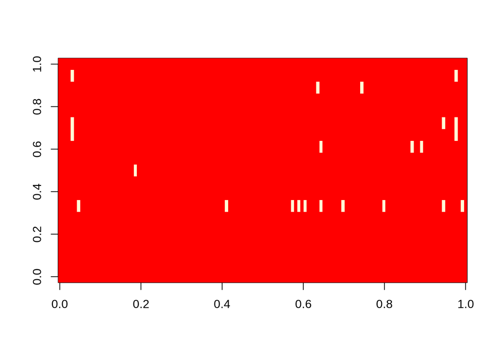

```r
image(is.na(survey)*1)
```

```r
sort(colSums(is.na(survey)))
```

```
##         Time           ID       Gender     Postcode  StatsCourse
##            0            0            0            0            0
##        Clubs    StudyLoad  SocialMedia    FBFriends ExerciseTime
##            0            0            0            0            0
##     Eyecolor       Cohort     Siblings          Pet      Working
##            0            0            1            2            2
##       Season        Grade         Home    StudyTime
##            2            3            3           10
```

```r
survey5 = survey[rowSums(is.na(survey))==0,c('Grade','StudyTime','Cohort','FBFriends','ExerciseTime','Working',"Pet","Home",'Clubs','Season')]
```

## PCA

```r
dataContinuous = as.data.frame(model.matrix(~.,survey5)[,-1])
pca = prcomp(dataContinuous)
summary(pca)$importance[,1:6]
```

```
##                              PC1      PC2      PC3      PC4      PC5
## Standard deviation     385.11304 21.91043 15.14169 10.40921 3.935082
## Proportion of Variance   0.99438  0.00322  0.00154  0.00073 0.000100
## Cumulative Proportion    0.99438  0.99760  0.99914  0.99987 0.999970
##                             PC6
## Standard deviation     1.768649
## Proportion of Variance 0.000020
## Cumulative Proportion  0.999990
```

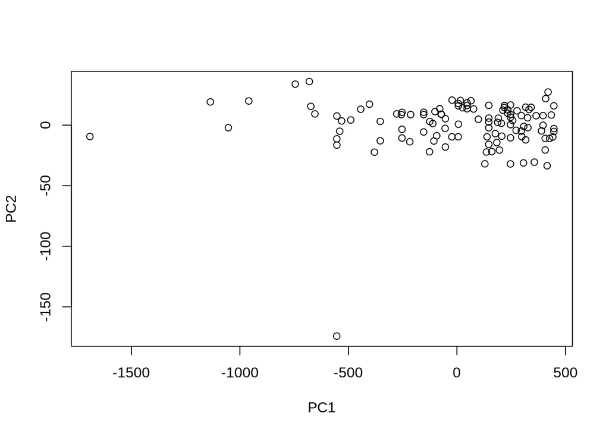

```r
plot(pca$x[,1:2])
```

```r
sort(pca$rotation[,1])
```

```
##           FBFriends             Working           StudyTime
##       -9.999763e-01       -5.642312e-03       -2.928470e-03
##        ExerciseTime               Grade              PetYes
##       -1.979718e-03       -1.582923e-03       -4.215810e-04
## CohortAMED3002.2019        SeasonSummer             HomeYes
##       -2.653185e-04       -2.243317e-04       -1.139230e-04
## CohortAMED3002.2018        SeasonWinter        SeasonSpring
##       -2.580473e-05       -2.804574e-06        1.070219e-04
##               Clubs
##        5.224180e-04
```

Now lets scale

```r
pca = prcomp(dataContinuous,scale = TRUE)
summary(pca)$importance[,1:6]
```

```
##                             PC1      PC2      PC3      PC4      PC5
## Standard deviation     1.387273 1.296258 1.247293 1.163047 1.070404
## Proportion of Variance 0.148040 0.129250 0.119670 0.104050 0.088140
## Cumulative Proportion  0.148040 0.277290 0.396970 0.501020 0.589150
##                              PC6
## Standard deviation     0.9980924
## Proportion of Variance 0.0766300
## Cumulative Proportion  0.6657800
```

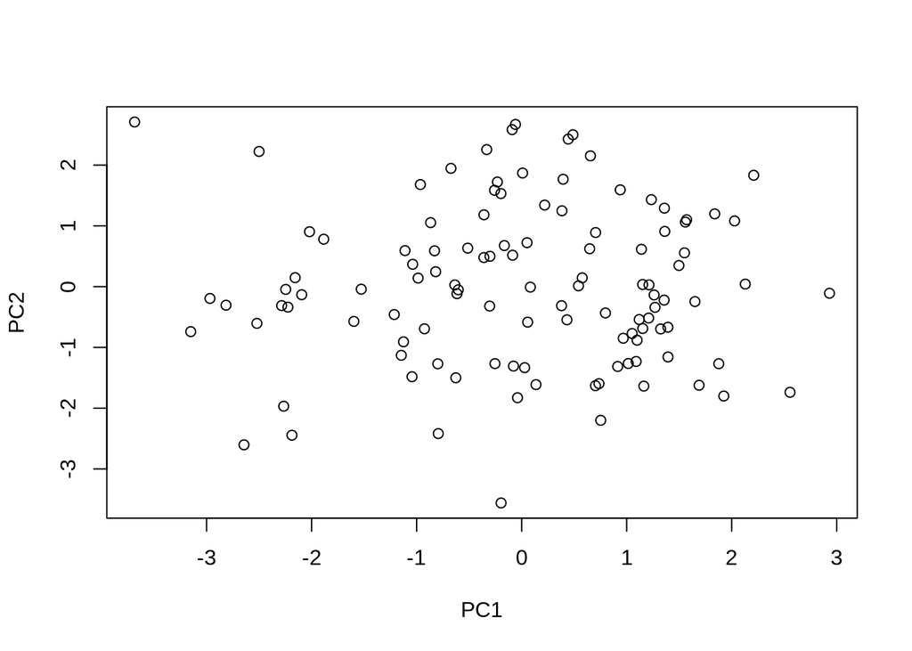

```r
plot(pca$x[,1:2])
```

```r
sort(pca$rotation[,1])
```

```
##             Working           FBFriends              PetYes
##        -0.489122068        -0.444297930        -0.425884842
##        ExerciseTime        SeasonSummer             HomeYes
##        -0.341766327        -0.305144246        -0.236578931
##               Grade CohortAMED3002.2018 CohortAMED3002.2019
##        -0.222285904        -0.130744543         0.003326099
##           StudyTime        SeasonSpring        SeasonWinter
##         0.013849416         0.084324309         0.124754378
##               Clubs
##         0.163437930
```

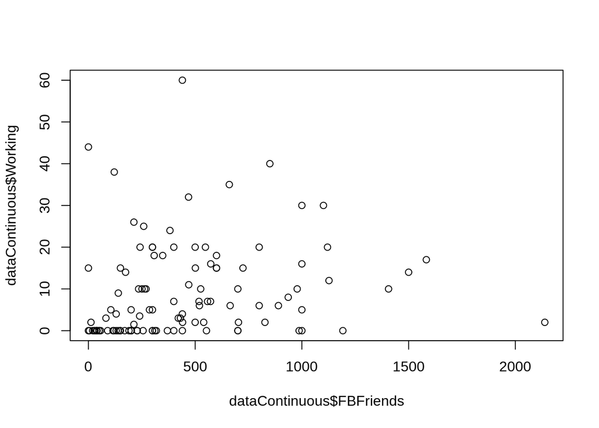

```r
plot(dataContinuous$FBFriends,dataContinuous$Working)
```

```r
cor(dataContinuous$FBFriends,dataContinuous$Working)
```

```
## [1] 0.1929523
```

```r
sort(pca$rotation[,2])
```

```
## CohortAMED3002.2019        SeasonSummer           StudyTime
##       -0.4539995821       -0.3100935537       -0.2513951299
##           FBFriends        SeasonWinter        ExerciseTime
##       -0.2363965296       -0.2041329002       -0.0817282541
##               Clubs              PetYes               Grade
##       -0.0618372796        0.0006288849        0.0200368201
##             Working CohortAMED3002.2018             HomeYes
##        0.2329637178        0.2996152775        0.3132503913
##        SeasonSpring
##        0.5328234732
```

```r
table(dataContinuous$CohortAMED3002.2019,dataContinuous$SeasonSpring)
```

```
##
##      0  1
##   0 63 26
##   1 22  2
```

```r
chisq.test(table(dataContinuous$CohortAMED3002.2019,dataContinuous$SeasonSpring))
```

```
##
##  Pearson's Chi-squared test with Yates' continuity correction
##
## data:  table(dataContinuous$CohortAMED3002.2019, dataContinuous$SeasonSpring)
## X-squared = 3.3722, df = 1, p-value = 0.0663
```

```r
table(survey$Cohort,survey$Season)
```

```
##
##                 Autumn Spring Summer Winter
##   STAT2012          20     22     27     12
##   AMED3002.2018      5      4      4      5
##   AMED3002.2019      8      2      9     10
```

## Clustering

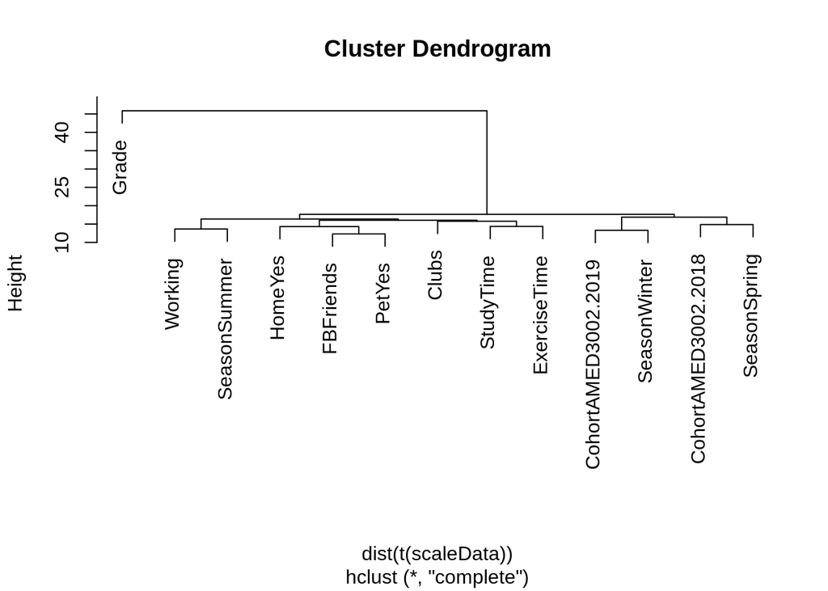

```r
scaleData = t(t(dataContinuous)/apply(dataContinuous,2,sd))
Hcluster = hclust(dist(t(scaleData)))
plot(Hcluster)
```